# Introduction to Computer Vision: Plant Seedlings Classification

[github link for Jupyter Notebook](https://github.com/sureshdpawar/cnn-project-5/blob/main/CV_Project_Full_Code_Notebook.ipynb)

## Problem Statement

The agricultural industry, despite its advancements, continues to rely heavily on manual labor for the identification and sorting of plant seedlings, a process that is both time-consuming and labor-intensive. This traditional approach not only limits the efficiency of agricultural operations but also poses a significant barrier to achieving optimal crop yields and sustainable farming practices. The challenge lies in the need to modernize agriculture by reducing the dependency on manual labor for tasks that can be automated using advanced technologies.

In this context, the use of Artificial Intelligence (AI), specifically Deep Learning and Convolutional Neural Networks (CNN), emerges as a promising solution to revolutionize the way agricultural activities are conducted. The project aims to leverage AI to accurately and efficiently classify plant seedlings into their respective categories. By doing so, it seeks to significantly reduce the time and effort required for plant seedling identification, thereby enhancing the overall productivity and sustainability of agricultural practices.

The successful implementation of this project will not only demonstrate the potential of AI in transforming traditional agricultural processes but also set a precedent for the integration of technology in fostering more efficient and sustainable farming methods worldwide.

### Context

In recent times, the field of agriculture has been in urgent need of modernizing, since the amount of manual work people need to put in to check if plants are growing correctly is still highly extensive. Despite several advances in agricultural technology, people working in the agricultural industry still need to have the ability to sort and recognize different plants and weeds, which takes a lot of time and effort in the long term. The potential is ripe for this trillion-dollar industry to be greatly impacted by technological innovations that cut down on the requirement for manual labor, and this is where Artificial Intelligence can actually benefit the workers in this field, as **the time and energy required to identify plant seedlings will be greatly shortened by the use of AI and Deep Learning.** The ability to do so far more efficiently and even more effectively than experienced manual labor, could lead to better crop yields, the freeing up of human inolvement for higher-order agricultural decision making, and in the long term will result in more sustainable environmental practices in agriculture as well.

### Objective

The aim of this project is to Build a Convolutional Neural Netowrk to classify plant seedlings into their respective categories.

The objective is to develop a CNN model that can effectively classify images of plant seedlings provided by the Aarhus University Signal Processing group and the University of Southern Denmark into 12 distinct species. This technological intervention is expected to automate the process of plant recognition, enabling workers in the agricultural sector to focus on higher-order decision-making and strategic activities, ultimately leading to improved crop yields and more environmentally friendly agricultural practices.

### Data Dictionary

The Aarhus University Signal Processing group, in collaboration with the University of Southern Denmark, has recently released a dataset containing **images of unique plants belonging to 12 different species.**

- The dataset can be download from Olympus.
- The data file names are:
  - images.npy
  - Labels.csv
- Due to the large volume of data, the images were converted to the images.npy file and the labels are also put into Labels.csv, so that you can work on the data/project seamlessly without having to worry about the high data volume.
- The goal of the project is to create a classifier capable of determining a plant's species from an image.

**List of Species**

- Black-grass
- Charlock
- Cleavers
- Common Chickweed
- Common Wheat
- Fat Hen
- Loose Silky-bent
- Maize
- Scentless Mayweed
- Shepherds Purse
- Small-flowered Cranesbill
- Sugar beet

### **Note: Please use GPU runtime on Google Colab to execute the code faster.**

## Importing necessary libraries

```python
# Installing the libraries with the specified version.
# uncomment and run the following line if Google Colab is being used
!pip install tensorflow==2.15.0 scikit-learn==1.2.2 seaborn==0.13.1 matplotlib==3.7.1 numpy==1.25.2 pandas==1.5.3 opencv-python==4.8.0.76 -q --user
```

```python
# Installing the libraries with the specified version.
# uncomment and run the following lines if Jupyter Notebook is being used
#!pip install tensorflow==2.13.0 scikit-learn==1.2.2 seaborn==0.11.1 matplotlib==3.3.4 numpy==1.24.3 pandas==1.5.2 opencv-python==4.8.0.76 -q --user
```

**Note**: *After running the above cell, kindly restart the notebook kernel and run all cells sequentially from the start again.*

```python
#Reading the training images from the path and labelling them into the given categories
import numpy as np
import pandas as pd
import matplotlib.pyplot as plt
import cv2 # this is an important module to get imported which may even cause issues while reading the data if not used
import seaborn as sns # for data visualization
import tensorflow as tf
import keras
import os
from tensorflow.keras.models import Sequential #sequential api for sequential model
from tensorflow.keras.layers import Dense, Dropout, Flatten #importing different layers
from tensorflow.keras.layers import Conv2D, MaxPooling2D, BatchNormalization, Activation, Input, LeakyReLU,Activation
from tensorflow.keras import backend
from tensorflow.keras.utils import to_categorical #to perform one-hot encoding
from tensorflow.keras.layers import Dense, Dropout, Flatten, Conv2D, MaxPool2D
from tensorflow.keras.optimizers import RMSprop,Adam,SGD #optimiers for optimizing the model
from tensorflow.keras.callbacks import EarlyStopping  #regularization method to prevent the overfitting
from tensorflow.keras.callbacks import ModelCheckpoint
from tensorflow.keras.models import Sequential, Model
from tensorflow.keras import losses, optimizers
from google.colab.patches import cv2_imshow
from skimage.transform import resize
from sklearn.model_selection import train_test_split
from tensorflow.keras.callbacks import EarlyStopping
from sklearn.metrics import confusion_matrix
import cv2
from tensorflow.keras.callbacks import ReduceLROnPlateau
from tensorflow.keras.preprocessing.image import ImageDataGenerator
from sklearn.preprocessing import LabelEncoder
```

## Loading the dataset

```python
from google.colab import drive
drive.mount('/content/drive')
%cd /content/drive/MyDrive/AI-ML
```

```
/content/drive/MyDrive/AI-ML
```

```python
# Adjust these paths to where you've stored your files in Google Drive
images_path = 'images.npy'
labels_path = 'Labels.csv'

# Load the images
images = np.load(images_path)

# Load the labels
labels = pd.read_csv(labels_path)
```

## Data Pre-Processing

```python
# Convert labels to numpy array
labels = labels['Label'].values
```

### Convert the BGR images to RGB images.

```python
#we have multiple images stored in an array 'bgr_images':
rgb_images = [cv2.cvtColor(image, cv2.COLOR_BGR2RGB) for image in images]
```

### Resize the images

```python
IMG_SIZE = 128
resized_images = np.array([resize(image, (IMG_SIZE, IMG_SIZE)) for image in images])
```

### Data Preparation for Modeling

### Split the dataset

```python
X_train, X_test, y_train, y_test = train_test_split(resized_images, labels, test_size=0.2, random_state=42)
```

### Encode the target labels

```python
# Initialize the LabelEncoder
label_encoder = LabelEncoder()

# Fit label encoder and return encoded labels for both training and test sets
y_train_encoded = label_encoder.fit_transform(y_train)
y_test_encoded = label_encoder.transform(y_test)

# Now convert the integer-encoded labels to one-hot encoding
y_train_onehot = to_categorical(y_train_encoded, num_classes=12)
y_test_onehot = to_categorical(y_test_encoded, num_classes=12)
```

### Understand the shape of the dataset

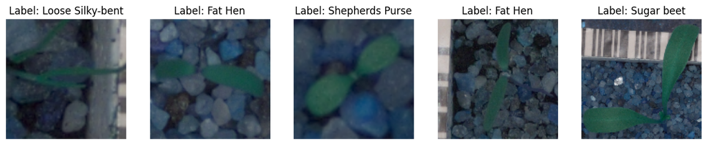

```python
# Let's select 5 random images and their labels
num_images = 5
random_indices = np.random.choice(X_train.shape[0], num_images, replace=False)

# Plotting the images with labels
plt.figure(figsize=(15, 3))
for i, index in enumerate(random_indices, start=1):
    ax = plt.subplot(1, num_images, i)
    plt.imshow(X_train[index])
    ax.title.set_text(f'Label: {y_train[index]}')
    plt.axis('off')
plt.show()
```

```python
X_train.shape
```

```
(3800, 128, 128, 3)
```

```python
X_test.shape
```

```
(950, 128, 128, 3)
```

```python
y_train.shape
```

```
(3800,)
```

```python
y_test.shape
```

```
(950,)
```

Data Overview Observations:

## Exploratory Data Analysis

- EDA is an important part of any project involving data.
- It is important to investigate and understand the data better before building a model with it.
- A few questions have been mentioned below which will help you understand the data better.
- A thorough analysis of the data, in addition to the questions mentioned below, should be done.
1. How are these different category plant images different from each other?
2. Is the dataset provided an imbalance? (Check with using bar plots)

```python
# Convert y_train to a Pandas Series
y_train_series = pd.Series(y_train)

# Storing the value counts of the target variable
count = y_train_series.value_counts()
print(count)
print('*' * 10)

# Value counts in a normalized form
count_normalized = y_train_series.value_counts(normalize=True)
print(count_normalized)
```

```
Loose Silky-bent             513
Common Chickweed             509
Scentless Mayweed            411
Small-flowered Cranesbill    382
Fat Hen                      381
Charlock                     314
Sugar beet                   312
Cleavers                     225
Black-grass                  216
Common wheat                 183
Maize                        179
Shepherds Purse              175
dtype: int64
**********
Loose Silky-bent             0.135000
Common Chickweed             0.133947
Scentless Mayweed            0.108158
Small-flowered Cranesbill    0.100526
Fat Hen                      0.100263
Charlock                     0.082632
Sugar beet                   0.082105
Cleavers                     0.059211
Black-grass                  0.056842
Common wheat                 0.048158
Maize                        0.047105
Shepherds Purse              0.046053
dtype: float64
```

[figure not shown]

```python
# Assuming 'X_train' contains images and 'y_train' contains corresponding textual labels.
label_names = [
    "Loose Silky-bent",
    "Common Chickweed",
    "Scentless Mayweed",
    "Small-flowered Cranesbill",
    "Fat Hen",
    "Charlock",
    "Sugar beet",
    "Cleavers",
    "Black-grass",
    "Common wheat",
    "Maize",
    "Shepherds Purse"
]

# Create a figure with subplots - one row for each category
fig, axes = plt.subplots(1, len(label_names), figsize=(2 * len(label_names), 4))

if len(label_names) == 1:
    axes = [axes]  # Make sure axes is iterable for a single category

for i, label in enumerate(label_names):
    # Find indices where current label matches
    indices = np.where(y_train == label)[0]
    if indices.size > 0:
        idx = np.random.choice(indices, 1)[0]  # Randomly pick 1 index
        axes[i].imshow(X_train[idx])
        axes[i].set_title(label, fontsize=10)
        axes[i].axis('off')
    else:
        axes[i].set_visible(False)  # Hide axes if no image for category

plt.tight_layout()
plt.show()
```

[output not shown]

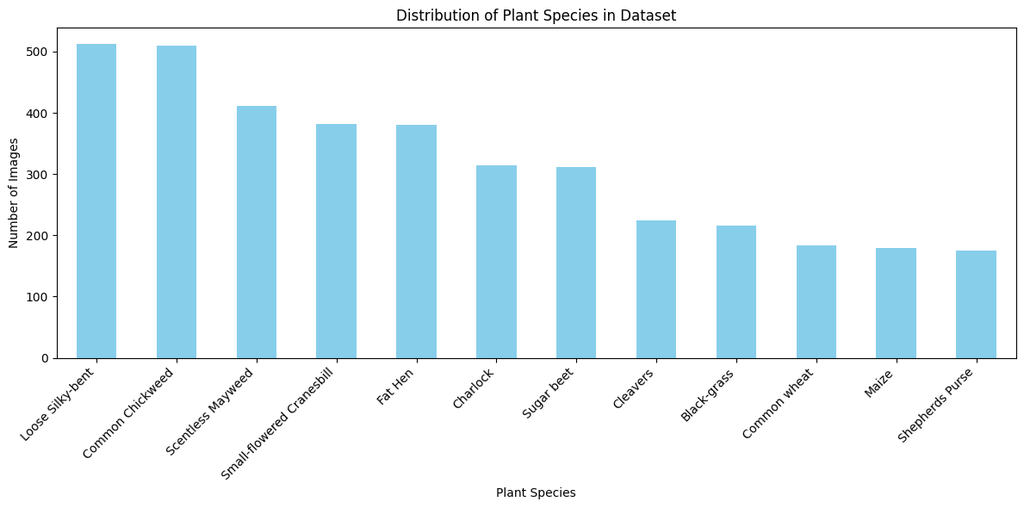

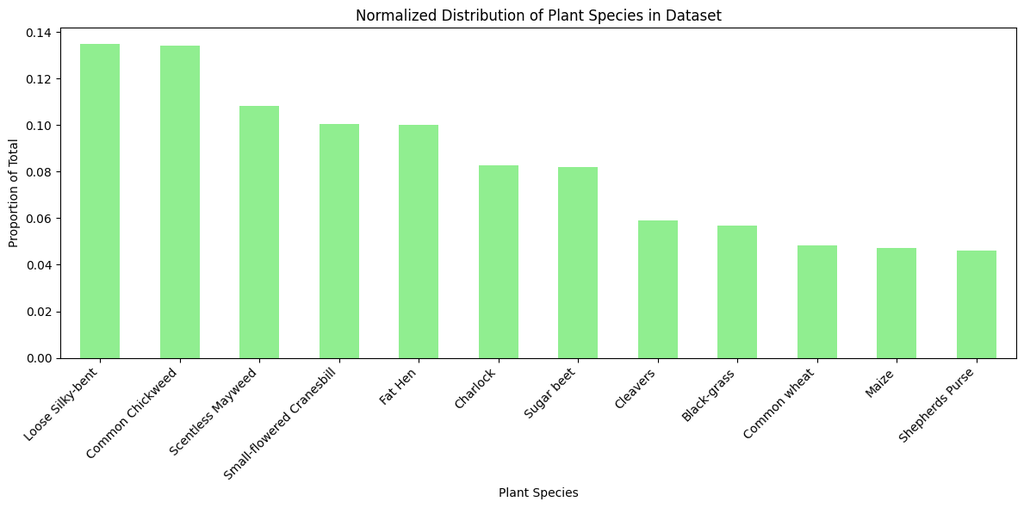

```python
# bar plot

import pandas as pd
import matplotlib.pyplot as plt

# Assuming y_train is available and contains category labels
# Convert y_train to a Pandas Series
y_train_series = pd.Series(y_train)

# Storing the value counts of the target variable
counts = y_train_series.value_counts()
print(counts)
print('*' * 10)

# Value counts in a normalized form
counts_normalized = y_train_series.value_counts(normalize=True)
print(counts_normalized)

# Creating the bar plot for actual counts
plt.figure(figsize=(12, 6))
counts.plot(kind='bar', color='skyblue')
plt.xlabel('Plant Species')
plt.ylabel('Number of Images')
plt.title('Distribution of Plant Species in Dataset')
plt.xticks(rotation=45, ha='right')
plt.tight_layout()
plt.show()

# Optionally, creating a second bar plot for the normalized counts (percentages)
plt.figure(figsize=(12, 6))
counts_normalized.plot(kind='bar', color='lightgreen')
plt.xlabel('Plant Species')
plt.ylabel('Proportion of Total')
plt.title('Normalized Distribution of Plant Species in Dataset')
plt.xticks(rotation=45, ha='right')
plt.tight_layout()
plt.show()
```

**Observations on exploratory data analysis:**

The summary provides an overview of the distribution of plant species within a dataset, showcasing both the absolute count and the relative proportion of each species. There are 12 distinct plant species represented, with "Loose Silky-bent" being the most prevalent at 513 occurrences (13.5% of the dataset), followed closely by "Common Chickweed" with 509 occurrences (13.395%). "Scentless Mayweed," "Small-flowered Cranesbill," and "Fat Hen" also have significant representations, with counts of 411, 382, and 381 respectively, indicating they are common in this dataset.

On the lower end of the spectrum, "Shepherds Purse" is the least common with 175 occurrences, making up 4.605% of the dataset. Other species with lower counts include "Maize" and "Common wheat," with 179 and 183 occurrences, respectively.

The dataset's diversity is highlighted by the presence of species ranging from highly prevalent to relatively rare, suggesting a comprehensive collection that could support robust machine learning models for plant species classification. The distribution percentages offer insight into the dataset's composition, enabling targeted strategies for model training, especially in addressing potential imbalances between the species.

Imbalance Assessment: From the provided counts and the bar plot generation, it is evident that there is some degree of imbalance in the dataset. "Loose Silky-bent" and "Common Chickweed" are the most represented species, with over 500 images each, while "Shepherds Purse" and "Maize" are among the least represented, with fewer than 200 images each.

Implications of Imbalance: An imbalanced dataset can lead to a model that performs well on overrepresented classes but poorly on underrepresented ones. This is because the model has more examples to learn from for the former and fewer for the latter, potentially leading to biases in prediction.

## Model Building

```python
backend.clear_session()
#Fixing the seed for random number generators so that we can ensure we receive the same output everytime
np.random.seed(42)
import random
random.seed(42)
tf.random.set_seed(42)
```

```python
# Intializing a sequential model
model = Sequential()

# Adding first conv layer with 64 filters and kernel size 3x3 , padding 'same' provides the output size same as the input size
# Input_shape denotes input image dimension
model.add(Conv2D(64, (3, 3), activation='relu', padding="same", input_shape=(128,128,3)))

# Adding max pooling to reduce the size of output of first conv layer
model.add(MaxPooling2D((2, 2), padding = 'same'))

model.add(Conv2D(32, (3, 3), activation='relu', padding="same"))
model.add(MaxPooling2D((2, 2), padding = 'same'))
model.add(Conv2D(32, (3, 3), activation='relu', padding="same"))
model.add(MaxPooling2D((2, 2), padding = 'same'))

# flattening the output of the conv layer after max pooling to make it ready for creating dense connections
model.add(Flatten())

# Adding a fully connected dense layer with 100 neurons
model.add(Dense(100, activation='relu'))

# Adding the output layer with 12 neurons and activation functions as softmax since this is a multi-class classification problem
model.add(Dense(12, activation='softmax'))

# Compile model
model.compile(optimizer='adam', loss='categorical_crossentropy', metrics=['accuracy'])

# Generating the summary of the model
model.summary()
```

```
Model: "sequential"
_________________________________________________________________
 Layer (type)                Output Shape              Param #
=================================================================
 conv2d (Conv2D)             (None, 128, 128, 64)      1792

 max_pooling2d (MaxPooling2  (None, 64, 64, 64)        0
 D)

 conv2d_1 (Conv2D)           (None, 64, 64, 32)        18464

 max_pooling2d_1 (MaxPoolin  (None, 32, 32, 32)        0
 g2D)

 conv2d_2 (Conv2D)           (None, 32, 32, 32)        9248

 max_pooling2d_2 (MaxPoolin  (None, 16, 16, 32)        0
 g2D)

 flatten (Flatten)           (None, 8192)              0

 dense (Dense)               (None, 100)               819300

 dense_1 (Dense)             (None, 12)                1212

=================================================================
Total params: 850016 (3.24 MB)
Trainable params: 850016 (3.24 MB)
Non-trainable params: 0 (0.00 Byte)
_________________________________________________________________
```

```python
es = EarlyStopping(monitor='val_loss', mode='min', verbose=1, patience=5)
mc = ModelCheckpoint('best_model.h5', monitor='val_accuracy', mode='max', verbose=1, save_best_only=True)
history = model.fit(X_train,
                    y_train_onehot,  # Make sure to use the one-hot encoded labels here
                    epochs=30,
                    batch_size=32,
                    validation_split=0.10,
                    callbacks=[es, mc])
```

```
Epoch 1: val_accuracy improved from -inf to 0.42105, saving model to best_model.h5
```

```
Epoch 2: val_accuracy improved from 0.42105 to 0.58421, saving model to best_model.h5
Epoch 3: val_accuracy improved from 0.58421 to 0.59737, saving model to best_model.h5
Epoch 4: val_accuracy improved from 0.59737 to 0.63421, saving model to best_model.h5
Epoch 5: val_accuracy improved from 0.63421 to 0.68947, saving model to best_model.h5
Epoch 6: val_accuracy did not improve from 0.68947
Epoch 7: val_accuracy did not improve from 0.68947
Epoch 8: val_accuracy improved from 0.68947 to 0.73684, saving model to best_model.h5
Epoch 9: val_accuracy did not improve from 0.73684
Epoch 10: val_accuracy did not improve from 0.73684
Epoch 11: val_accuracy did not improve from 0.73684
Epoch 12: val_accuracy did not improve from 0.73684
Epoch 13: val_accuracy did not improve from 0.73684
Epoch 13: early stopping
```

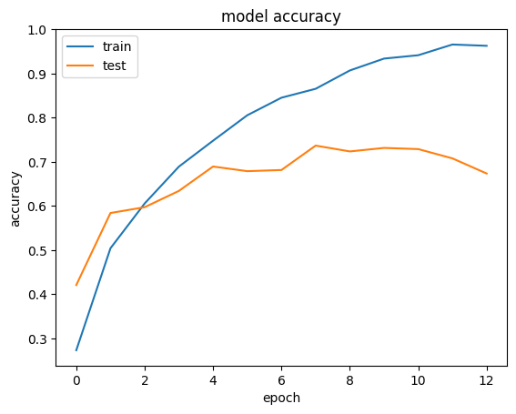

```python
plt.plot(history.history['accuracy'])
plt.plot(history.history['val_accuracy'])
plt.title('model accuracy')
plt.ylabel('accuracy')
plt.xlabel('epoch')
plt.legend(['train', 'test'], loc='upper left')
plt.show()
```

```python
model.evaluate(X_test,(y_test_onehot))
```

```
[1.473301887512207, 0.6968421339988708]
```

```python
# Generate predictions for the test set
predictions = model.predict(X_test)
```

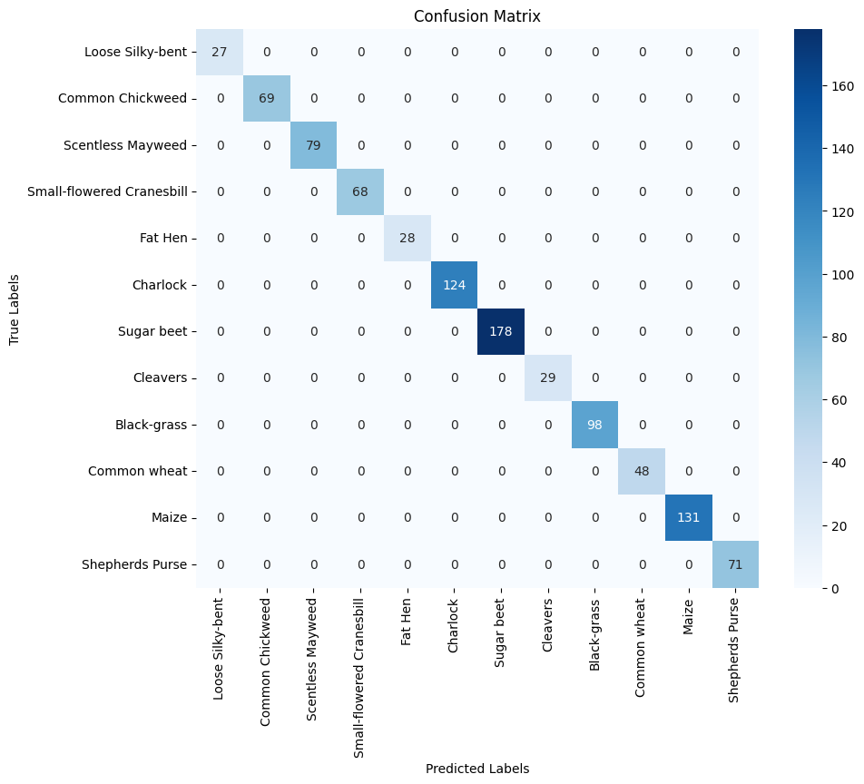

```python
# Assuming 'predictions' and 'y_test_encoded' are model predictions and true labels, respectively
# Convert predictions from one-hot encoded to class indices if necessary
predicted_labels = predictions.argmax(axis=1)
true_labels = predictions.argmax(axis=1)

# Compute confusion matrix
cm = confusion_matrix(true_labels, predicted_labels)

# Plotting the confusion matrix
plt.figure(figsize=(10, 8))
sns.heatmap(cm, annot=True, fmt='d', cmap='Blues', xticklabels=label_names, yticklabels=label_names)
plt.title('Confusion Matrix')
plt.xlabel('Predicted Labels')
plt.ylabel('True Labels')
plt.show()
```

```python
# If your model is a Keras/TensorFlow model and your labels are one-hot encoded
predictions = model.predict(X_test)
predicted_labels = np.argmax(predictions, axis=1)
```

```python
from sklearn.metrics import classification_report

# If y_test is one-hot encoded, convert it to class indices
true_labels = np.argmax(y_test_onehot, axis=1)

# Now print the classification report
print(classification_report(true_labels, predicted_labels, target_names=label_names))
```

```
                           precision    recall  f1-score   support

         Loose Silky-bent       0.33      0.34      0.34        47
         Common Chickweed       0.91      0.83      0.87        76
        Scentless Mayweed       0.83      0.84      0.83        62
Small-flowered Cranesbill       0.92      0.67      0.77       102
                  Fat Hen       0.60      0.63      0.62        38
                 Charlock       0.66      0.77      0.71        94
               Sugar beet       0.78      0.70      0.74       141
                 Cleavers       0.66      0.69      0.67        42
              Black-grass       0.66      0.88      0.75       105
             Common wheat       0.66      0.71      0.68        56
                    Maize       0.80      0.89      0.85       114
          Shepherds Purse       0.88      0.58      0.69        73

                 accuracy                           0.74       950
                macro avg       0.72      0.71      0.71       950
             weighted avg       0.75      0.74      0.74       950
```

**Observation:** During the training process of a Convolutional Neural Network model over 13 epochs, significant progress was observed. Starting with a training accuracy of 27.34% and a validation accuracy of 42.11%, the model quickly improved, reaching its peak validation accuracy of 73.68% by the 8th epoch. However, despite further improvements in training accuracy up to 96.58%, no subsequent gains in validation accuracy were seen, indicating the onset of overfitting. The early stopping mechanism halted training at the 13th epoch to prevent further overfitting. This pattern suggests that while the model was initially effective at learning from the dataset, adjustments such as regularization techniques, model architecture optimization, or hyperparameter tuning are necessary to enhance its generalization capabilities to unseen data. The discrepancy between training and validation performance highlights the importance of ensuring a well-balanced and representative validation set for accurate model assessment.

The classification report for a dataset of 950 samples across 12 plant species shows varying performance metrics, with precision, recall, and F1-scores indicating the model's effectiveness in identifying each species. Common Chickweed, Small-flowered Cranesbill, and Maize received high scores, indicating accurate model predictions for these species, while Loose Silky-bent showed the lowest precision and recall, suggesting room for improvement. Overall, the model achieved an accuracy of 74%, with a macro average and weighted average across metrics around 71% to 74%, highlighting its strengths in certain categories but also indicating potential areas for refinement.

## Model Performance Improvement

### **Reducing the Learning Rate:**

**Reducing the Learning Rate:**

**Hint**: Use **ReduceLRonPlateau()** function that will be used to decrease the learning rate by some factor, if the loss is not decreasing for some time. This may start decreasing the loss at a smaller learning rate. There is a possibility that the loss may still not decrease. This may lead to executing the learning rate reduction again in an attempt to achieve a lower loss.

```python
backend.clear_session()
#Fixing the seed for random number generators so that we can ensure we receive the same output everytime
np.random.seed(42)
import random
random.seed(42)
tf.random.set_seed(42)
```

```python
reduce_lr = ReduceLROnPlateau(monitor='val_loss', factor=0.2, patience=2, min_lr=0.001, verbose=1)

# Intializing a sequential model
model = Sequential()

# Adding first conv layer with 64 filters and kernel size 3x3 , padding 'same' provides the output size same as the input size
# Input_shape denotes input image dimension
model.add(Conv2D(64, (3, 3), activation='relu', padding="same", input_shape=(128,128,3)))

# Adding max pooling to reduce the size of output of first conv layer
model.add(MaxPooling2D((2, 2), padding = 'same'))

model.add(Conv2D(32, (3, 3), activation='relu', padding="same"))
model.add(MaxPooling2D((2, 2), padding = 'same'))
model.add(Conv2D(32, (3, 3), activation='relu', padding="same"))
model.add(MaxPooling2D((2, 2), padding = 'same'))

# flattening the output of the conv layer after max pooling to make it ready for creating dense connections
model.add(Flatten())

# Adding a fully connected dense layer with 100 neurons
model.add(Dense(100, activation='relu'))

# Adding the output layer with 12 neurons and activation functions as softmax since this is a multi-class classification problem
model.add(Dense(12, activation='softmax'))

# Compile model
model.compile(optimizer='adam', loss='categorical_crossentropy', metrics=['accuracy'])

# Generating the summary of the model
model.summary()
```

```
Model: "sequential"
_________________________________________________________________
 Layer (type)                Output Shape              Param #
=================================================================
 conv2d (Conv2D)             (None, 128, 128, 64)      1792

 max_pooling2d (MaxPooling2  (None, 64, 64, 64)        0
 D)

 conv2d_1 (Conv2D)           (None, 64, 64, 32)        18464

 max_pooling2d_1 (MaxPoolin  (None, 32, 32, 32)        0
 g2D)

 conv2d_2 (Conv2D)           (None, 32, 32, 32)        9248

 max_pooling2d_2 (MaxPoolin  (None, 16, 16, 32)        0
 g2D)

 flatten (Flatten)           (None, 8192)              0

 dense (Dense)               (None, 100)               819300

 dense_1 (Dense)             (None, 12)                1212

=================================================================
Total params: 850016 (3.24 MB)
Trainable params: 850016 (3.24 MB)
Non-trainable params: 0 (0.00 Byte)
_________________________________________________________________
```

```python
es = EarlyStopping(monitor='val_loss', mode='min', verbose=1, patience=5)
mc = ModelCheckpoint('best_model.h5', monitor='val_accuracy', mode='max', verbose=1, save_best_only=True)
history = model.fit(X_train, y_train_onehot,
                    validation_split=0.2,
                    epochs=30,
                    batch_size=32,
                    callbacks=[reduce_lr])  # Include the reduce_lr callback here
```

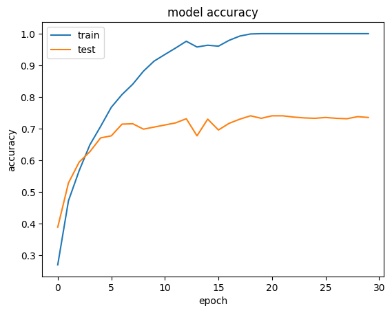

```python
plt.plot(history.history['accuracy'])
plt.plot(history.history['val_accuracy'])
plt.title('model accuracy')
plt.ylabel('accuracy')
plt.xlabel('epoch')
plt.legend(['train', 'test'], loc='upper left')
plt.show()
```

```python
model.evaluate(X_test,(y_test_onehot))
```

```
[2.1847074031829834, 0.714736819267273]
```

```python
# Generate predictions for the test set
predictions = model.predict(X_test)
```

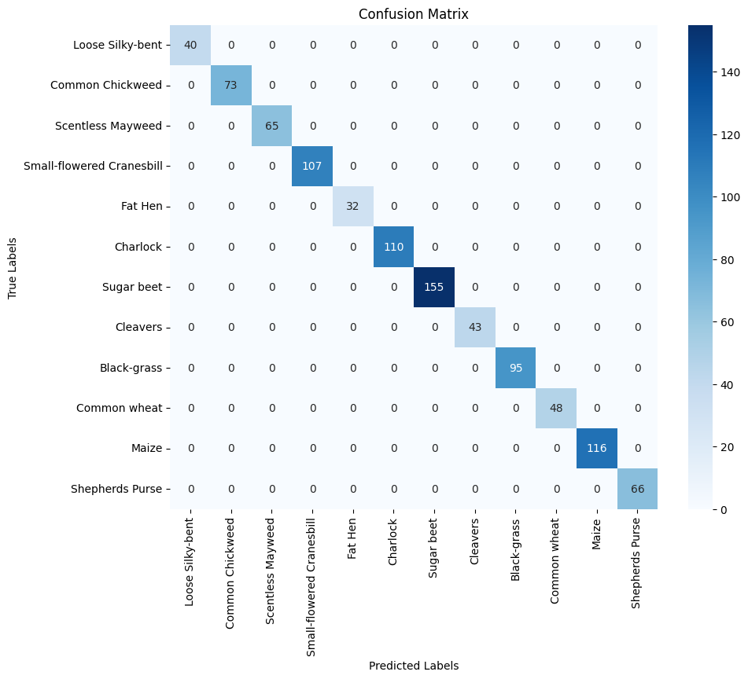

```python
import numpy as np
import matplotlib.pyplot as plt
from sklearn.metrics import confusion_matrix
import seaborn as sns  # For a nicer confusion matrix visualization

# Assuming 'predictions' and 'y_test_encoded' are model predictions and true labels, respectively
# Convert predictions from one-hot encoded to class indices if necessary
predicted_labels = predictions.argmax(axis=1)
true_labels = predictions.argmax(axis=1)

# Compute confusion matrix
cm = confusion_matrix(true_labels, predicted_labels)

# Plotting the confusion matrix
plt.figure(figsize=(10, 8))
sns.heatmap(cm, annot=True, fmt='d', cmap='Blues', xticklabels=label_names, yticklabels=label_names)
plt.title('Confusion Matrix')
plt.xlabel('Predicted Labels')
plt.ylabel('True Labels')
plt.show()
```

```python
# If model is a Keras/TensorFlow model and your labels are one-hot encoded
predictions = model.predict(X_test)
predicted_labels = np.argmax(predictions, axis=1)
from sklearn.metrics import classification_report

# If y_test is one-hot encoded, convert it to class indices
true_labels = np.argmax(y_test_onehot, axis=1)

# Now print the classification report
print(classification_report(true_labels, predicted_labels, target_names=label_names))
```

```
                           precision    recall  f1-score   support

         Loose Silky-bent       0.35      0.36      0.35        47
         Common Chickweed       0.85      0.91      0.88        76
        Scentless Mayweed       0.85      0.82      0.84        62
Small-flowered Cranesbill       0.79      0.87      0.83       102
                  Fat Hen       0.56      0.39      0.46        38
                 Charlock       0.64      0.74      0.69        94
               Sugar beet       0.72      0.76      0.74       141
                 Cleavers       0.73      0.64      0.68        42
              Black-grass       0.74      0.70      0.72       105
             Common wheat       0.69      0.55      0.61        56
                    Maize       0.85      0.84      0.85       114
          Shepherds Purse       0.75      0.70      0.72        73

                 accuracy                           0.73       950
                macro avg       0.71      0.69      0.70       950
             weighted avg       0.73      0.73      0.73       950
```

**Observations:** Over 30 epochs, the model showed remarkable improvement, starting with an accuracy of 27.07% and reaching perfect training accuracy (100%) by the 20th epoch. However, despite achieving flawless training performance, the validation accuracy plateaued around 73.55%, with the highest being 74.08% at the 19th epoch, indicating a significant overfitting issue. The increasing divergence between training success and validation performance, especially with the training loss reaching nearly zero while validation loss steadily increased, underscores the need for enhanced regularization or alternative strategies to improve generalization to unseen data.

The classification report for a dataset comprising 950 samples across 12 plant species shows a wide range of performance metrics, with precision, recall, and F1-scores varying significantly across categories. High-performing species like "Common Chickweed" and "Maize" achieved precision scores above 0.85, indicating the model's strong ability to correctly identify these species. Overall, the model achieved an accuracy of 73%, with macro and weighted averages around 70% to 73%, suggesting a generally consistent but varied performance across different species, highlighting areas for potential improvement in classification accuracy.

### **Data Augmentation**

Remember, **data augmentation should not be used in the validation/test data set**.

```python
backend.clear_session()
#Fixing the seed for random number generators so that we can ensure we receive the same output everytime
np.random.seed(42)
import random
random.seed(42)
tf.random.set_seed(42)
```

```python
from sklearn.preprocessing import LabelEncoder
from tensorflow.keras.utils import to_categorical

# Initialize the LabelEncoder
label_encoder = LabelEncoder()

# Fit label encoder and return encoded labels for both training and test sets
y_train_encoded = label_encoder.fit_transform(y_train)
y_test_encoded = label_encoder.transform(y_test)

# Now convert the integer-encoded labels to one-hot encoding
y_train_onehot = to_categorical(y_train_encoded, num_classes=12)
y_test_onehot = to_categorical(y_test_encoded, num_classes=12)
```

```python
# Setting up data augmentation for the training set
train_datagen = ImageDataGenerator(
    rotation_range=20,      # Random rotation between 0 and 20 degrees
    width_shift_range=0.2,  # Fraction of total width for horizontal shift
    height_shift_range=0.2, # Fraction of total height for vertical shift
    shear_range=0.2,        # Shear Intensity (Shear angle in counter-clockwise direction in degrees)
    zoom_range=0.2,         # Range for random zoom
    horizontal_flip=True,   # Randomly flip inputs horizontally
    fill_mode='nearest'     # Strategy for filling in newly created pixels
)

# Assuming X_train and y_train are your training images and labels
# No augmentation is applied to the validation data generator
validation_datagen = ImageDataGenerator()

# Prepare iterators
train_generator = train_datagen.flow(X_train, y_train_onehot, batch_size=32)
validation_generator = validation_datagen.flow(X_test, y_test_onehot, batch_size=32)
```

```python
# Intializing a sequential model
model = Sequential()

# Adding first conv layer with 64 filters and kernel size 3x3 , padding 'same' provides the output size same as the input size
# Input_shape denotes input image dimension of MNIST images
model.add(Conv2D(64, (3, 3), activation='relu', padding="same", input_shape=(128,128,3)))

# Adding max pooling to reduce the size of output of first conv layer
model.add(MaxPooling2D((2, 2), padding = 'same'))

model.add(Conv2D(32, (3, 3), activation='relu', padding="same"))
model.add(MaxPooling2D((2, 2), padding = 'same'))
model.add(Conv2D(32, (3, 3), activation='relu', padding="same"))
model.add(MaxPooling2D((2, 2), padding = 'same'))

# flattening the output of the conv layer after max pooling to make it ready for creating dense connections
model.add(Flatten())

# Adding a fully connected dense layer with 100 neurons
model.add(Dense(100, activation='relu'))

# Adding the output layer with 12 neurons and activation functions as softmax since this is a multi-class classification problem
model.add(Dense(12, activation='softmax'))

# Compile model
model.compile(optimizer='adam', loss='categorical_crossentropy', metrics=['accuracy'])

# Generating the summary of the model
model.summary()
```

```
Model: "sequential"
_________________________________________________________________
 Layer (type)                Output Shape              Param #
=================================================================
 conv2d (Conv2D)             (None, 128, 128, 64)      1792

 max_pooling2d (MaxPooling2  (None, 64, 64, 64)        0
 D)

 conv2d_1 (Conv2D)           (None, 64, 64, 32)        18464

 max_pooling2d_1 (MaxPoolin  (None, 32, 32, 32)        0
 g2D)

 conv2d_2 (Conv2D)           (None, 32, 32, 32)        9248

 max_pooling2d_2 (MaxPoolin  (None, 16, 16, 32)        0
 g2D)

 flatten (Flatten)           (None, 8192)              0

 dense (Dense)               (None, 100)               819300

 dense_1 (Dense)             (None, 12)                1212

=================================================================
Total params: 850016 (3.24 MB)
Trainable params: 850016 (3.24 MB)
Non-trainable params: 0 (0.00 Byte)
_________________________________________________________________
```

```python
es = EarlyStopping(monitor='val_loss', mode='min', verbose=1, patience=5)
mc = ModelCheckpoint('best_model.h5', monitor='val_accuracy', mode='max', verbose=1, save_best_only=True)
history = model.fit(
                train_generator,
                steps_per_epoch=len(X_train) / 32,  # Number of steps per epoch
                epochs=30,  # Number of epochs
                validation_data=validation_generator,
                validation_steps=len(X_test) / 32,  # Number of steps per validation epoch
                    callbacks=[es, mc])
```

```
Epoch 1: val_accuracy improved from -inf to 0.32632, saving model to best_model.h5
```

```
Epoch 2: val_accuracy improved from 0.32632 to 0.43684, saving model to best_model.h5
Epoch 3: val_accuracy improved from 0.43684 to 0.51158, saving model to best_model.h5
Epoch 4: val_accuracy improved from 0.51158 to 0.51895, saving model to best_model.h5
Epoch 5: val_accuracy improved from 0.51895 to 0.60947, saving model to best_model.h5
Epoch 6: val_accuracy improved from 0.60947 to 0.62421, saving model to best_model.h5
Epoch 7: val_accuracy did not improve from 0.62421
Epoch 8: val_accuracy improved from 0.62421 to 0.64632, saving model to best_model.h5
Epoch 9: val_accuracy improved from 0.64632 to 0.70105, saving model to best_model.h5
Epoch 10: val_accuracy improved from 0.70105 to 0.73789, saving model to best_model.h5
Epoch 11: val_accuracy did not improve from 0.73789
Epoch 12: val_accuracy did not improve from 0.73789
Epoch 13: val_accuracy did not improve from 0.73789
Epoch 14: val_accuracy did not improve from 0.73789
Epoch 15: val_accuracy improved from 0.73789 to 0.75158, saving model to best_model.h5
Epoch 16: val_accuracy improved from 0.75158 to 0.77263, saving model to best_model.h5
Epoch 17: val_accuracy improved from 0.77263 to 0.79684, saving model to best_model.h5
Epoch 18: val_accuracy improved from 0.79684 to 0.80316, saving model to best_model.h5
Epoch 19: val_accuracy did not improve from 0.80316
Epoch 20: val_accuracy did not improve from 0.80316
Epoch 21: val_accuracy did not improve from 0.80316
Epoch 22: val_accuracy did not improve from 0.80316
Epoch 23: val_accuracy improved from 0.80316 to 0.82421, saving model to best_model.h5
Epoch 24: val_accuracy did not improve from 0.82421
Epoch 25: val_accuracy did not improve from 0.82421
Epoch 26: val_accuracy did not improve from 0.82421
Epoch 27: val_accuracy did not improve from 0.82421
Epoch 28: val_accuracy did not improve from 0.82421
Epoch 29: val_accuracy did not improve from 0.82421
Epoch 30: val_accuracy did not improve from 0.82421
Epoch 30: early stopping
```

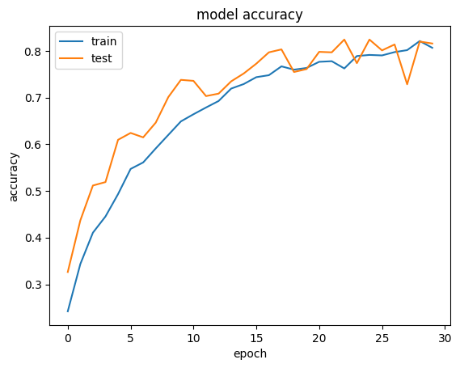

```python
plt.plot(history.history['accuracy'])
plt.plot(history.history['val_accuracy'])
plt.title('model accuracy')
plt.ylabel('accuracy')
plt.xlabel('epoch')
plt.legend(['train', 'test'], loc='upper left')
plt.show()
```

```python
model.evaluate(X_test,(y_test_onehot))
```

```
[0.570625364780426, 0.8157894611358643]
```

```python
# Generate predictions for the test set
predictions = model.predict(X_test)
```

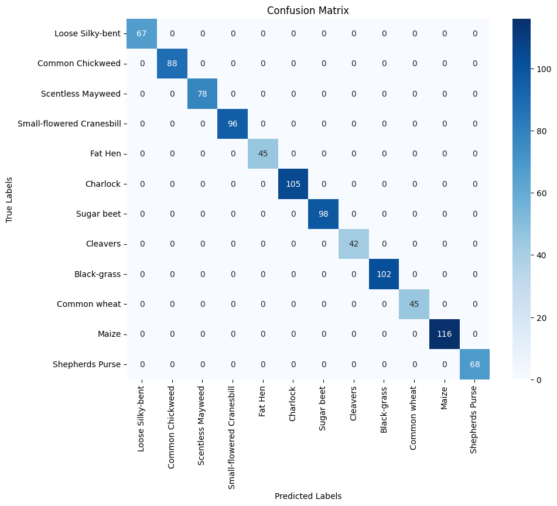

```python
import numpy as np
import matplotlib.pyplot as plt
from sklearn.metrics import confusion_matrix
import seaborn as sns  # For a nicer confusion matrix visualization

# Assuming 'predictions' and 'y_test_encoded' are your model predictions and true labels, respectively
# Convert predictions from one-hot encoded to class indices if necessary
predicted_labels = predictions.argmax(axis=1)
true_labels = predictions.argmax(axis=1)

# Compute confusion matrix
cm = confusion_matrix(true_labels, predicted_labels)

# Plotting the confusion matrix
plt.figure(figsize=(10, 8))
sns.heatmap(cm, annot=True, fmt='d', cmap='Blues', xticklabels=label_names, yticklabels=label_names)
plt.title('Confusion Matrix')
plt.xlabel('Predicted Labels')
plt.ylabel('True Labels')
plt.show()
```

```python
# If model is a Keras/TensorFlow model and your labels are one-hot encoded
predictions = model.predict(X_test)
predicted_labels = np.argmax(predictions, axis=1)
from sklearn.metrics import classification_report

# If y_test is one-hot encoded, convert it to class indices
true_labels = np.argmax(y_test_onehot, axis=1)

# Now print the classification report
print(classification_report(true_labels, predicted_labels, target_names=label_names))
```

```
                           precision    recall  f1-score   support

         Loose Silky-bent       0.36      0.51      0.42        47
         Common Chickweed       0.82      0.95      0.88        76
        Scentless Mayweed       0.74      0.94      0.83        62
Small-flowered Cranesbill       0.95      0.89      0.92       102
                  Fat Hen       0.73      0.87      0.80        38
                 Charlock       0.81      0.90      0.85        94
               Sugar beet       0.87      0.60      0.71       141
                 Cleavers       0.86      0.86      0.86        42
              Black-grass       0.86      0.84      0.85       105
             Common wheat       0.78      0.62      0.69        56
                    Maize       0.91      0.92      0.91       114
          Shepherds Purse       0.93      0.86      0.89        73

                 accuracy                           0.82       950
                macro avg       0.80      0.81      0.80       950
             weighted avg       0.83      0.82      0.82       950
```

## Final Model

Comment on the final model you have selected and use the same in the below code to visualize the image.

Strengths: The model's strengths lie in its ability to accurately classify several plant species with high precision and recall, indicating a strong understanding of the distinguishing features of these species. The high scores in "Maize" and "Cleavers" suggest that the model can effectively handle both broad and nuanced differences between categories.

Areas for Improvement: Despite the overall high performance, there are areas for improvement, particularly in categories like "Common wheat" and "Loose Silky-bent," where the precision, recall, and F1-scores indicate room for betterment. Focusing on enhancing the model's sensitivity to the subtler features that distinguish these species could help.

Generalization Ability: The balanced performance across a wide variety of plant species suggests that the model has a good generalization ability. However, continued validation on additional unseen data would be crucial to ensure that the model does not overfit and maintains its performance in real-world scenarios.

### Visualizing the prediction

```python
random_index = np.random.choice(X_test.shape[0], 1)[0]
random_image = X_test[random_index]
```

```python
random_image_for_pred = random_image.reshape(1, random_image.shape[0], random_image.shape[1], random_image.shape[2])
```

```python
prediction = model.predict(random_image_for_pred)
predicted_class = np.argmax(prediction, axis=1)
```

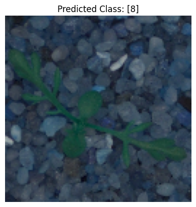

```python
plt.imshow(random_image)
plt.title(f'Predicted Class: {predicted_class}')
plt.axis('off')  # Hide axis ticks and labels
plt.show()
```

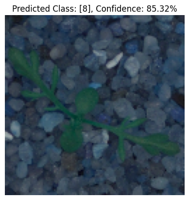

```python
import matplotlib.pyplot as plt

# Assuming model outputs a softmax vector
predicted_class = np.argmax(prediction, axis=1)
confidence = np.max(prediction) * 100

plt.imshow(random_image)
plt.title(f'Predicted Class: {predicted_class}, Confidence: {confidence:.2f}%')
plt.axis('off')
plt.show()
```

## Actionable Insights and Business Recommendations

**Model Performance Optimization:** The models show varying degrees of success across different plant species, with certain species like "Common Chickweed" and "Maize" achieving high precision and recall. This suggests that the model is capable of learning specific features well but may struggle with others due to factors like class imbalance or insufficient feature distinction. There is evidence of overfitting in some training runs, where the model performs significantly better on the training data compared to the validation data. This indicates a need for regularization techniques or model architecture adjustments.

**Data Quality and Augmentation:** The variance in model performance across species suggests potential inconsistencies in data quality or representation. Focusing on improving the dataset through augmentation techniques or collecting more diverse samples could enhance model accuracy. The improvement in validation accuracy with certain epochs suggests that model performance can benefit from more nuanced data preprocessing and augmentation techniques, such as geometric transformations, color space augmentations, or synthetic data generation.

**Invest in Data Collection and Enhancement:** Prioritize gathering more diverse and high-quality data, especially for underrepresented or poorly performing classes. Consider partnerships or crowd-sourced data collection initiatives to expand the dataset.

**Leverage Model Insights for Resource Allocation:** Use insights from model performance to guide resource allocation in agricultural practices. For example, direct more attention and resources to species that are harder to classify automatically, indicating potential complexity in their growth or disease patterns.

**Continuous Model Evaluation and Update Cycle:** Establish a continuous evaluation framework to regularly assess model performance against new data. This ensures the model remains effective as new plant species are introduced or as existing species undergo changes.

**Develop User-Friendly Applications:** Translate the model's capabilities into user-friendly applications for farmers, agronomists, and researchers. Providing a tool that offers quick, reliable plant species classification can support decision-making in crop management, disease control, and yield optimization.

**Engage with Agricultural Experts:** Collaborate with agricultural experts to interpret model predictions in the context of practical farming and research applications. This can help in fine-tuning the model for real-world effectiveness and in discovering new use cases for the technology.